# Lesson 11 Solution

LTC James K. Starling

Last compiled on 08 February, 2022

## Introduction

This lab is based on data from an online game, Epidemic (https://stat2games.sites.grinnell.edu/). In this game, there is an outbreak of new viruses. Two potential medicines are currently being tested to stop the viruses from spreading. We will refer to these medicines as the Red Medicine and the Blue Medicine. Both have shown some evidence of success when compared against a placebo. However, neither is 100% effective and more testing is needed to determine which treatment is best. Your task is to determine the best treatment strategy to stop the spread of the viruses.

- Download the Epidemic Data from Teams.
- Import the dataset into R and filter it to include only observations from Level 1.
- Use the Count and Destroyed variables to create a new variable PercentDestroyed.
- Organize your R code so that plots appear in the order that they are requested in this prompt.
- Ensure all plots have informative axes and titles.
- Use comments to indicate the task, subsection, and question number you are answering.

```r
# Load packages and data
library(tidyverse)
library(ggResidpanel)

# epidemic <- read_csv("https://raw.githubusercontent.com/jkstarling/MA376/main/epidemicdata.csv")
setwd("c:/Users/james.starling/OneDrive - West Point/Teaching/MA376/JimsLessons/Block II/LSN11/")
epidemic <- read_csv("epidemicdata.csv")

# Filter to only use observations from Level 1
level1 <- epidemic %>%
  filter(Level == "1")

# Create new variable PercentDestroyed
level1 <- level1 %>%
  mutate(percDestroyed = Destroyed/Count,
         Medicine = as.factor(Medicine),
         Virus = as.factor(Virus),
         Location = as.factor(Location))
```

## TASK #1 Explore the Data

### Analysis of Medicine Type

1.Plot the effectiveness of the Medicines using PercentDestroyed as the response variable. Does one medicine seem better than the other?

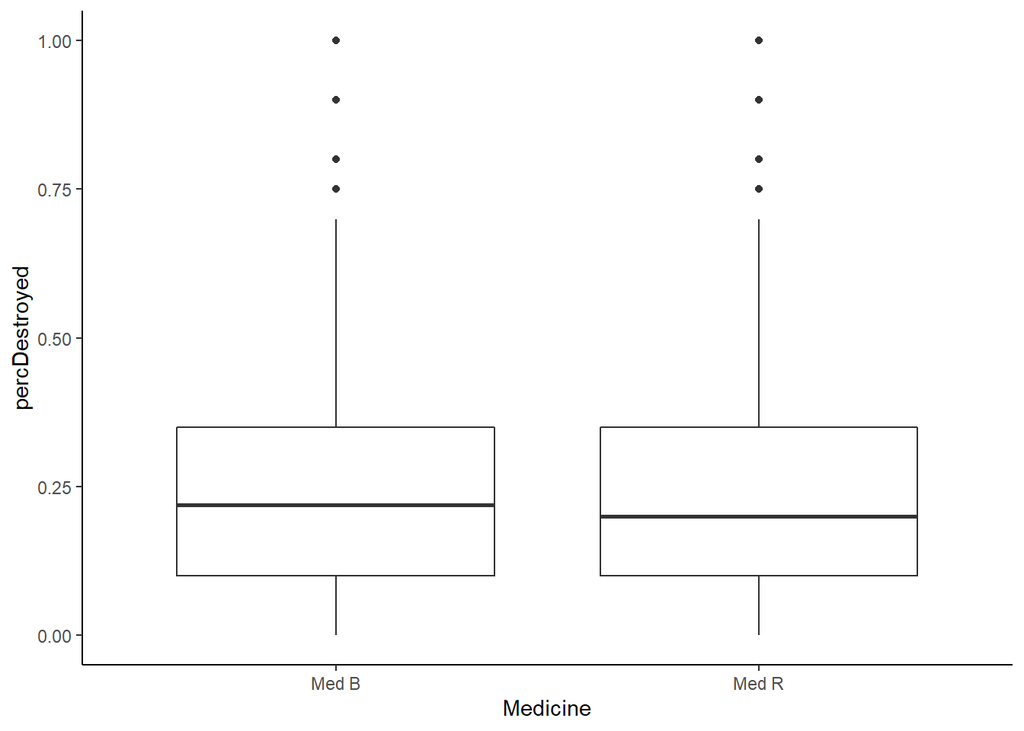

```r
level1 %>%
  ggplot(aes(x = Medicine, y = percDestroyed)) +
  geom_boxplot()+
  theme_classic()
```

Not really. They appear to have the same effectiveness.

2.Modify the plot from question 1 to explore whether the effectiveness of the medicines depends on the Type of Virus. What are your conclusions?

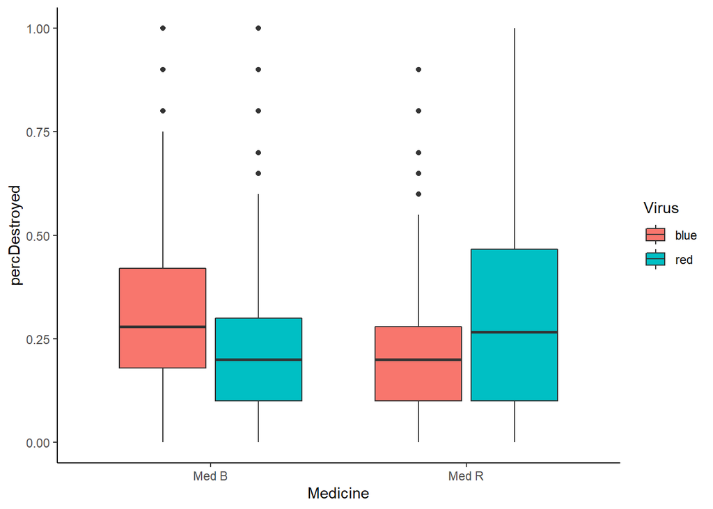

```r
level1 %>%
  ggplot(aes(x = Medicine, y = percDestroyed, fill=Virus)) +
  geom_boxplot()+
  theme_classic()
```

```r
# level1 %>%
#   ggplot(aes(x = Medicine, y = percDestroyed)) + facet_wrap(~Virus) +
#   geom_boxplot()+
#   theme_classic()
```

Medicine B appears to be more effect against the blue virus while medicine red appears to be more effective against the red virus.

### Analysis of Turret Location

3.Produce a plot of effectiveness of the Locations using PercentDestroyed as the response variable. Does location seem to matter?

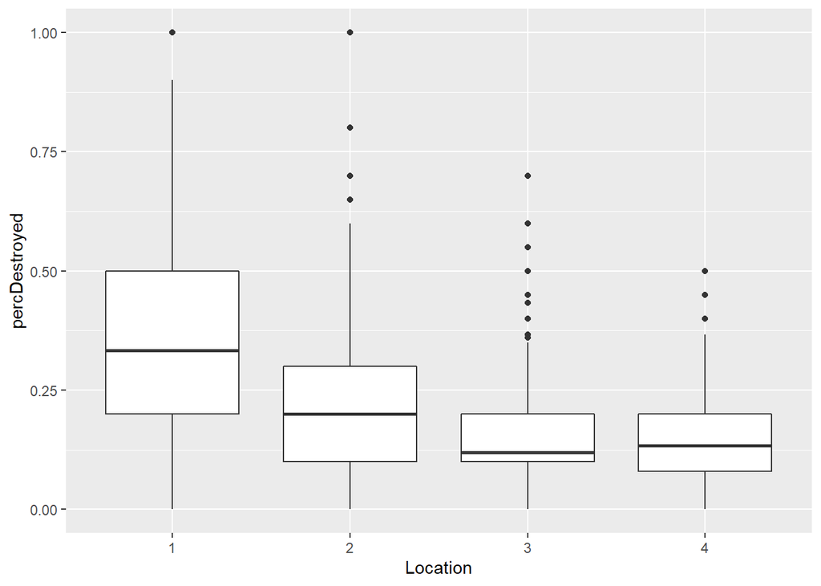

```r
level1 %>%
  ggplot(aes(x = Location, y = percDestroyed)) +
  geom_boxplot()
```

4.Modify the plot from question 3 to explore whether the effectiveness of the locations depends on the Type of Virus. What are your conclusions?

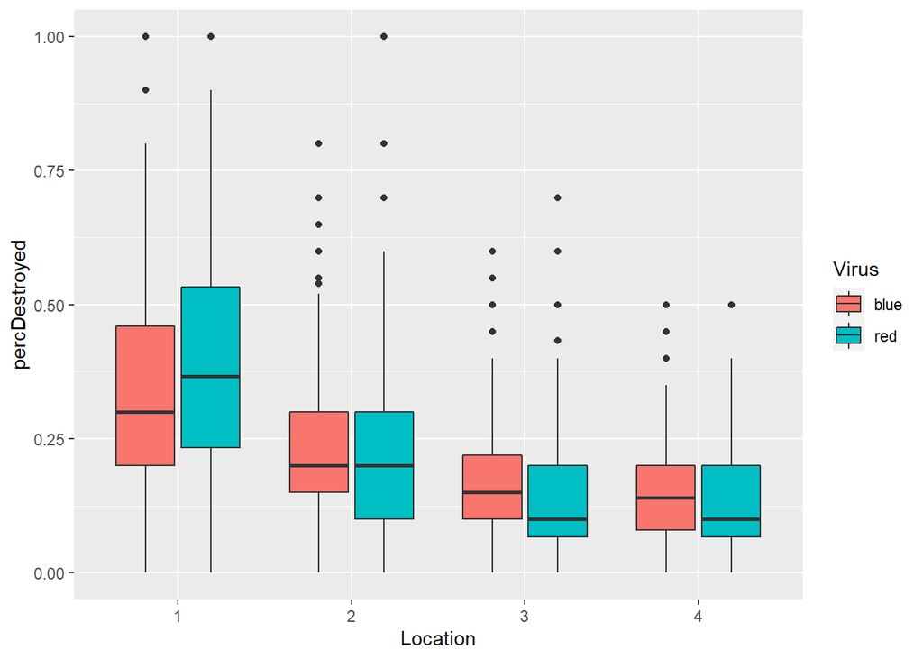

```r
level1 %>%
  ggplot(aes(x = Location, y = percDestroyed, fill = Virus)) +
  geom_boxplot()
```

Effectiveness is relatively similar for both viruses for each location.

### Preliminary Conclusions

5.Based on the results from this preliminary analysis, what location and medicine combinations do you think are most effective. Why?

## TASK #2 Draw Inferences Beyond the Data

### Two-variable model (with no interaction)

1.Use R to fit a model on `percDestroyed` with the main effects of `Location` and `Medicine` with no interaction. Your code should include both a regression and ANOVA table.

```r
two_var.lm <- lm(percDestroyed ~ Medicine + Location, data = level1)
summary(two_var.lm)
```

```
##
## Call:
## lm(formula = percDestroyed ~ Medicine + Location, data = level1)
##
## Residuals:
##      Min       1Q   Median       3Q      Max
## -0.37360 -0.10461 -0.02247  0.08087  0.78087
##
## Coefficients:
##                Estimate Std. Error t value Pr(>|t|)
## (Intercept)    0.373597   0.002293 162.901  < 2e-16 ***
## MedicineMed R -0.018986   0.002476  -7.669 1.84e-14 ***
## Location2     -0.135485   0.003235 -41.886  < 2e-16 ***
## Location3     -0.217797   0.003022 -72.080  < 2e-16 ***
## Location4     -0.216023   0.004885 -44.224  < 2e-16 ***
## ---
## Signif. codes:  0 '***' 0.001 '**' 0.01 '*' 0.05 '.' 0.1 ' ' 1
##
## Residual standard error: 0.153 on 15338 degrees of freedom
## Multiple R-squared:  0.2852, Adjusted R-squared:  0.285
## F-statistic:  1530 on 4 and 15338 DF,  p-value: < 2.2e-16
```

```r
anova(two_var.lm)
```

```
## Analysis of Variance Table
##
## Response: percDestroyed
##              Df Sum Sq Mean Sq  F value    Pr(>F)
## Medicine      1   0.28   0.285   12.147  0.000493 ***
## Location      3 143.05  47.684 2035.809 < 2.2e-16 ***
## Residuals 15338 359.25   0.023
## ---
## Signif. codes:  0 '***' 0.001 '**' 0.01 '*' 0.05 '.' 0.1 ' ' 1
```

2.Write the appropriate hypotheses for the model in words.

$H_0:$ There is no difference in the mean percent destroyed for these four treatments $H_a:$ At least one long-run treatment mean differs from the others.

3.Are the model assumptions met? Be sure your code includes the appropriate plots to support your answer.

```r
level1 %>%
  group_by(Medicine, Location) %>%
  summarize(SD = sd(percDestroyed))
```

```
## # A tibble: 8 x 3
## # Groups:   Medicine [2]
##   Medicine Location     SD
##   <fct>    <fct>     <dbl>
## 1 Med B    1        0.191
## 2 Med B    2        0.138
## 3 Med B    3        0.103
## 4 Med B    4        0.104
## 5 Med R    1        0.198
## 6 Med R    2        0.127
## 7 Med R    3        0.0865
## 8 Med R    4        0.0954
```

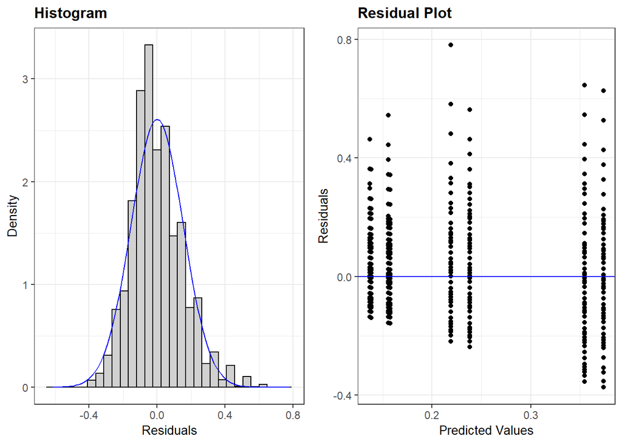

```r
resid_panel(two_var.lm, plots = c('hist','resid'))
```

The residuals appear to be normally distributed but the largest sd is larger than twice the smallest sd.

4.What are your conclusions? Is effectiveness in defeating the virus impacted by location and/or medicine type?

Yes. Both Location and Medicine type have a significant association with effectiveness. This is shown by the high F-stat >4 and small p-values <0.05.

### Interaction model

5.A friend tells you an interaction between location and medicine means there is an association between location and medicine. Is your friend correct? Explain.

No. An interaction between location and medicine means that the effect of one variable on effectiveness is modified by the value of the other variable.

6.Use R to fit a model with the main effects of location and medicine with an interaction. Your code should include both a regression and ANOVA table.

```r
interact.lm <- lm(percDestroyed ~ Medicine*Location, data = level1)
summary(interact.lm)
```

```
##
## Call:
## lm(formula = percDestroyed ~ Medicine * Location, data = level1)
##
## Residuals:
##      Min       1Q   Median       3Q      Max
## -0.37105 -0.10438 -0.02608  0.07895  0.77369
##
## Coefficients:
##                          Estimate Std. Error t value Pr(>|t|)
## (Intercept)              0.371046   0.002739 135.485  < 2e-16 ***
## MedicineMed R           -0.014109   0.003786  -3.726 0.000195 ***
## Location2               -0.140654   0.004664 -30.159  < 2e-16 ***
## Location3               -0.206309   0.004195 -49.180  < 2e-16 ***
## Location4               -0.213590   0.006756 -31.613  < 2e-16 ***
## MedicineMed R:Location2  0.010028   0.006469   1.550 0.121134
## MedicineMed R:Location3 -0.024549   0.006047  -4.060 4.93e-05 ***
## MedicineMed R:Location4 -0.004623   0.009775  -0.473 0.636265
## ---
## Signif. codes:  0 '***' 0.001 '**' 0.01 '*' 0.05 '.' 0.1 ' ' 1
##
## Residual standard error: 0.1529 on 15335 degrees of freedom
## Multiple R-squared:  0.2865, Adjusted R-squared:  0.2861
## F-statistic: 879.5 on 7 and 15335 DF,  p-value: < 2.2e-16
```

```r
anova(interact.lm)
```

```
## Analysis of Variance Table
##
## Response: percDestroyed
##                      Df Sum Sq Mean Sq   F value    Pr(>F)
## Medicine              1   0.28   0.285   12.1665 0.0004879 ***
## Location              3 143.05  47.684 2039.0136 < 2.2e-16 ***
## Medicine:Location     3   0.63   0.212    9.0481 5.553e-06 ***
## Residuals         15335 358.62   0.023
## ---
## Signif. codes:  0 '***' 0.001 '**' 0.01 '*' 0.05 '.' 0.1 ' ' 1
```

```r
#or
summary(aov(percDestroyed~Medicine*Location, data = level1))
```

```
##                      Df Sum Sq Mean Sq  F value   Pr(>F)
## Medicine              1    0.3    0.28   12.166 0.000488 ***
## Location              3  143.1   47.68 2039.014  < 2e-16 ***
## Medicine:Location     3    0.6    0.21    9.048 5.55e-06 ***
## Residuals         15335  358.6    0.02
## ---
## Signif. codes:  0 '***' 0.001 '**' 0.01 '*' 0.05 '.' 0.1 ' ' 1
```

7.Write the appropriate hypotheses for the model in words.

$H_0:$ There is no interaction between location and medicine. $H_a:$ There is an interaction between location and medicine.

8.Are the model assumptions met? Be sure your code includes the appropriate plots to support your answer.

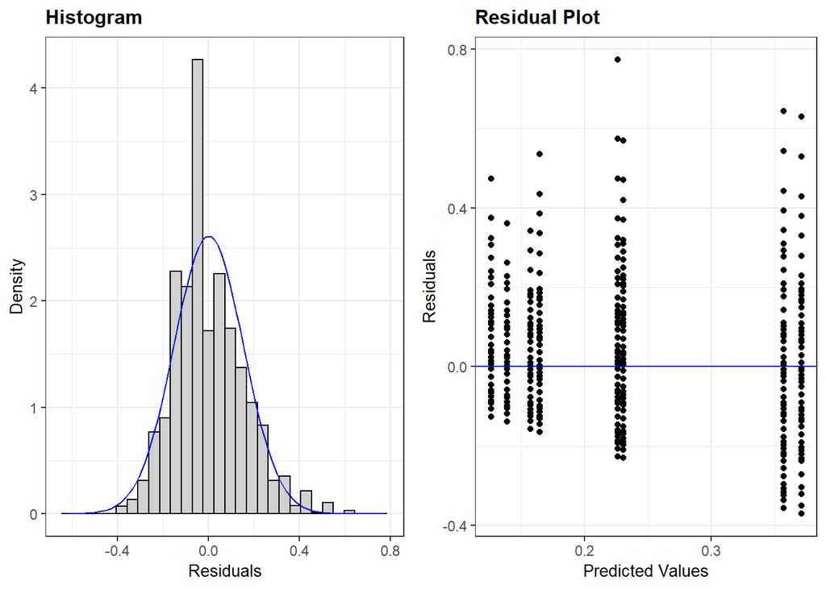

```r
resid_panel(interact.lm, plots = c('hist', 'resid'))
```

9.Is there a significant interaction between location and medicine? If not, are either of the main effects significant?

Yes. There is a significant interaction and the main effects for both location and medicine are both significant.

### Conclusions

10.Based on your result, which settings (location/medicine) would you recommend for use in game play based on the models? Why?

I would recommend location 1 and medicine blue as these two selections have the highest average effectiveness.